# Gov50: Practice Exam #2

Tyler Simko

The `US_births_2000_2014` dataset from the `fivethirtyeight` package contains information on how many people were born in the US every day from 1/1/2000 until 12/31/2014. Let’s use it for this practice exam!

## Question 1

Replicate the following plot below. Here are a few hints:

1. Notice you have a plot by year with a summarized variable (mean births) for each month. That is, a single row in the dataset for each month-year combination. How can you achieve this data structure?
2. The theme is `theme_minimal()`.
3. The month names are too long to show them all at once, so I used a `scale` function with `breaks` and `labels` arguments to display only the three below. Hint: the blank month labels are actually empty strings.
4. If you notice your year plots are too close together, you can try `theme(panel.spacing = unit(0.8, "lines")` and change 0.8 to your liking.

When you’re done, take a look at the pattern by year. You’ll notice some similarities. When are the months with the highest amount of births? The lowest?

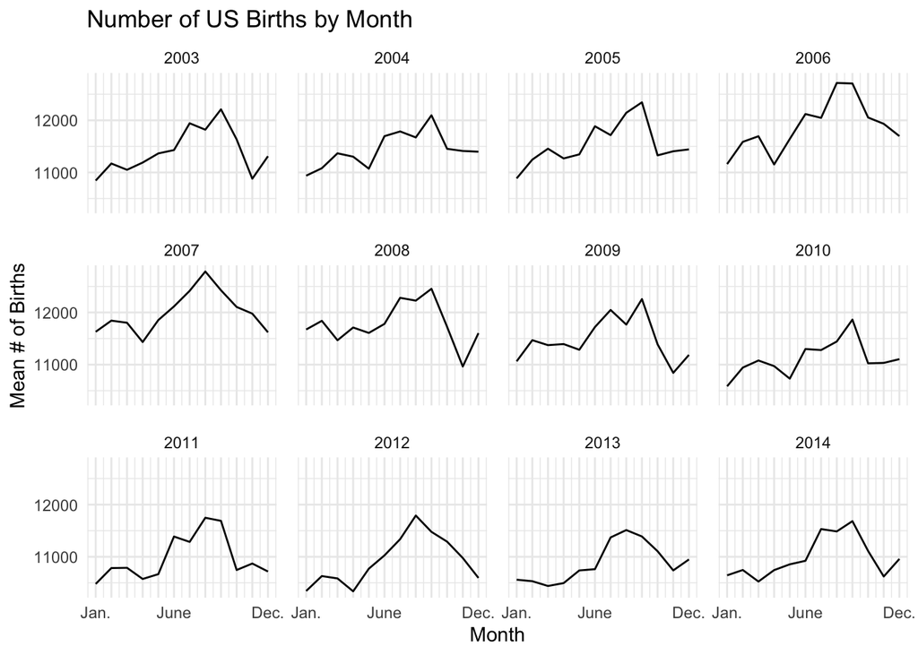

## Question 2

This dataset is very comprehensive - it has data on every single day! We are going to simulate two scenarios where you don’t have all of this data. Create two new tibbles:

1. `random_sample`: a tibble created by taking a random sample of size 500 (using `sample_n()` from `US_births_2000_2014`).
2. `nonrandom_sample`: a tibble created by filtering `US_births_2000_2014` to observations from Septembers only.

Then, calculate three averages (just run them in the console or store the values, don’t print them to the PDF):

1. The average number of births in `US_births_2000_2014`.
2. The average number of births in `random_sample`.
3. The average number of births in `nonrandom_sample`.

What do you notice about these estimates?

## Question 3

Let’s use bootstrap to calculate uncertainty around both of our sample estimates. Create a function called `bootstrap_estimate` that:

1. Takes one tibble argument called `x`.
2. Creates 1000 bootstrap samples of `x`.
3. Estimates the average number of births in each sample and stores them in a column called `avg_births`.
4. Returns this modified tibble.

Then, run this function on your `random_sample` and `nonrandom_sample` objects separately and store the results into objects called `boot_random` and `boot_nonrandom`. Finally, using the quantile function on each of these objects, create 95% confidence intervals for your estimates and store them in objects called `boot_ci_rand` and `boot_ci_nonrand`. Do either of your confidence intervals contain the true value? Which one?

## Question 4

Create a plot that visualizes both of your bootstrap distributions alongside a vertical line for the true average number of births in the `US_births_2000_2014` dataset.

To get both of your samples in the same tibble, you could use the `bind_rows` function to stack your datasets on top of each other. You could also use the `.id` argument to create a new column when binding that specifies which dataset each observationi in your final dataset comes from. For example, `bind_rows(object_A, object_B, .id = "sample_type")` would create a new column called `sample_type` that is `1` for rows in `object_A` and `2` for rows in `object_B`.

Your plot must:

1. Visualize both bootstrap distributions alongside the true answer.
2. Clearly identify which distribution corresponds to which sample. One way to do this is by editing the legend with a `scale` function.
3. Use colors and a theme other than the default.
4. Have a title and appropriate axis labels.

## Question 5

Create and interpret two intercept-only models to estimate average number of births in the population using `stan_glm`. One model will use the `boot_random` dataset, while another will use the `boot_nonrandom` dataset. Create 95% confidence intervals for both of these models. Then, respond to the following questions **for each model**.

1. Describe what each of your models is estimating. What are the samples and what is the population? Are each of your samples a good representation of the population? What are some positives and negatives of each?
2. Describe and interpret your “Median” and “MAD_SD” values for each model. Interpret them substantively (i.e. what do the numbers represent in the context of the question) and statistically (i.e. describe what the numbers mean in the context of what your model estimated).
3. Describe and interpret your confidence intervals.